# Project: Identify Customer Segments

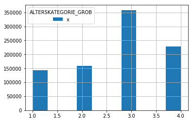

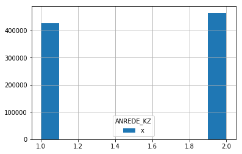

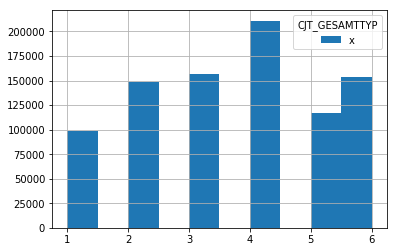

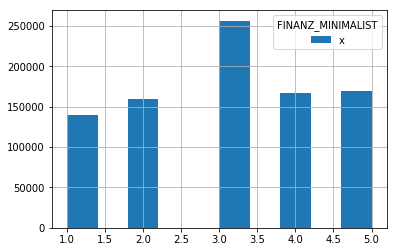

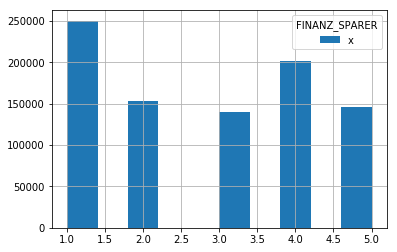

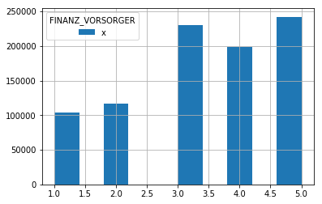

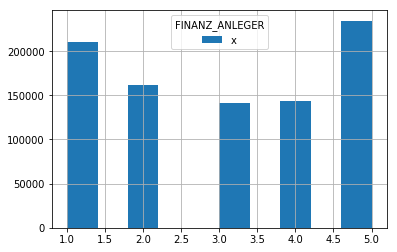

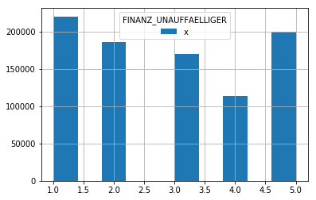

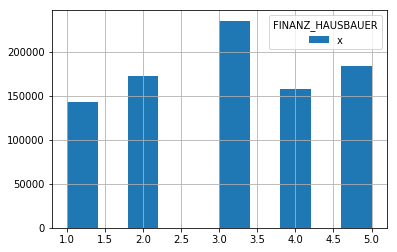

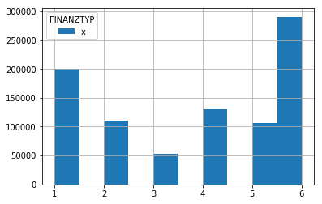

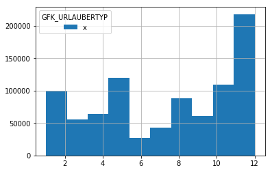

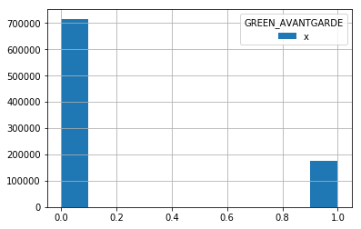

[67 more figures not shown]

```python
undrop_index = undrop_list_index(azdias)

undrop_df = azdias.iloc[:, undrop_index]
undrop_df


for und in undrop_df.columns:
    undrop_df[und].hist()
    plt.legend(['x','y'], title = und)
    plt.show()
```

#### Discussion 1.1.3: Assess Missing Data in Each Row

Missing data more than 34% are:-

'AGER_TYP' 'GEBURTSJAHR' 'TITEL_KZ' 'ALTER_HH' 'KK_KUNDENTYP' 'KBA05_BAUMAX'

All data shown are highly concentrated on small range and far scarce, therefore it may mean only 1 thing or 2 perhaps in big picture, either YES or NO, perhaps

### Step 1.2: Select and Re-Encode Features

Checking for missing data isn't the only way in which you can prepare a dataset for analysis. Since the unsupervised learning techniques to be used will only work on data that is encoded numerically, you need to make a few encoding changes or additional assumptions to be able to make progress. In addition, while almost all of the values in the dataset are encoded using numbers, not all of them represent numeric values. Check the third column of the feature summary (`feat_info`) for a summary of types of measurement.

- For numeric and interval data, these features can be kept without changes.
- Most of the variables in the dataset are ordinal in nature. While ordinal values may technically be non-linear in spacing, make the simplifying assumption that the ordinal variables can be treated as being interval in nature (that is, kept without any changes).
- Special handling may be necessary for the remaining two variable types: categorical, and 'mixed'.

In the first two parts of this sub-step, you will perform an investigation of the categorical and mixed-type features and make a decision on each of them, whether you will keep, drop, or re-encode each. Then, in the last part, you will create a new data frame with only the selected and engineered columns.

Data wrangling is often the trickiest part of the data analysis process, and there's a lot of it to be done here. But stick with it: once you're done with this step, you'll be ready to get to the machine learning parts of the project!

```python
# How many features are there of each data type?

print(undrop_df.dtypes.describe())
df_dtype = undrop_df.dtypes
print(df_dtype[df_dtype == 'float64'].count())
print(df_dtype[df_dtype == 'int64'].count())
print(df_dtype[df_dtype == 'object'].count())
```

```
count          79
unique          3
top       float64
freq           51
dtype: object
51
24
4
```

#### Step 1.2.1: Re-Encode Categorical Features

For categorical data, you would ordinarily need to encode the levels as dummy variables. Depending on the number of categories, perform one of the following:

- For binary (two-level) categoricals that take numeric values, you can keep them without needing to do anything.
- There is one binary variable that takes on non-numeric values. For this one, you need to re-encode the values as numbers or create a dummy variable.
- For multi-level categoricals (three or more values), you can choose to encode the values using multiple dummy variables (e.g. via [OneHotEncoder](http://scikit-learn.org/stable/modules/generated/sklearn.preprocessing.OneHotEncoder.html)), or (to keep things straightforward) just drop them from the analysis. As always, document your choices in the Discussion section.

```python
# Assess categorical variables: which are binary, which are multi-level, and
# which one needs to be re-encoded?
obj_data = []
for items in undrop_df.dtypes[undrop_df.dtypes == 'object'].index:
    obj_data.append(undrop_df.columns.get_loc(items))

undrop_df.iloc[:, obj_data]
```

|  | OST_WEST_KZ | CAMEO_DEUG_2015 | CAMEO_DEU_2015 | CAMEO_INTL_2015 |
| --- | --- | --- | --- | --- |
| 0 | NaN | NaN | NaN | NaN |
| 1 | W | 8 | 8A | 51 |
| 2 | W | 4 | 4C | 24 |
| 3 | W | 2 | 2A | 12 |
| 4 | W | 6 | 6B | 43 |
| 5 | W | 8 | 8C | 54 |
| 6 | W | 4 | 4A | 22 |
| 7 | W | 2 | 2D | 14 |
| 8 | W | 1 | 1A | 13 |
| 9 | W | 1 | 1E | 15 |
| 10 | W | 9 | 9D | 51 |
| 11 | NaN | NaN | NaN | NaN |
| 12 | W | 6 | 6B | 43 |
| 13 | W | 5 | 5C | 33 |
| 14 | NaN | NaN | NaN | NaN |
| 15 | W | 8 | 8B | 41 |
| 16 | W | 7 | 7A | 41 |
| 17 | NaN | NaN | NaN | NaN |
| 18 | W | 4 | 4C | 24 |
| 19 | W | 5 | 5D | 34 |
| 20 | W | 4 | 4C | 24 |
| 21 | W | 9 | 9E | 55 |
| 22 | W | 9 | 9D | 51 |
| 23 | W | 6 | 6B | 43 |
| 24 | NaN | NaN | NaN | NaN |
| 25 | W | 5 | 5C | 33 |
| 26 | W | NaN | NaN | NaN |
| 27 | W | 9 | 9B | 51 |
| 28 | W | 1 | 1A | 13 |
| 29 | W | 2 | 2A | 12 |
| ... | ... | ... | ... | ... |
| 891191 | W | 6 | 6C | 44 |
| 891192 | W | 5 | 5B | 32 |
| 891193 | W | 6 | 6B | 43 |
| 891194 | W | 4 | 4C | 24 |
| 891195 | W | 8 | 8D | 55 |
| 891196 | W | 4 | 4B | 23 |
| 891197 | W | 3 | 3C | 24 |
| 891198 | W | 2 | 2C | 14 |
| 891199 | W | 8 | 8A | 51 |
| 891200 | W | 9 | 9A | 52 |
| 891201 | W | 7 | 7A | 41 |
| 891202 | W | 8 | 8B | 41 |
| 891203 | W | 3 | 3D | 25 |
| 891204 | W | 3 | 3C | 24 |
| 891205 | W | 5 | 5E | 34 |
| 891206 | W | 3 | 3D | 25 |
| 891207 | W | 7 | 7A | 41 |
| 891208 | W | 2 | 2C | 14 |
| 891209 | W | 8 | 8A | 51 |
| 891210 | W | 8 | 8B | 41 |
| 891211 | W | 9 | 9D | 51 |
| 891212 | W | 9 | 9D | 51 |
| 891213 | W | 5 | 5E | 34 |
| 891214 | W | 3 | 3A | 23 |
| 891215 | W | 5 | 5A | 31 |
| 891216 | W | 7 | 7A | 41 |
| 891217 | W | 9 | 9D | 51 |
| 891218 | W | 4 | 4C | 24 |
| 891219 | W | 9 | 9D | 51 |
| 891220 | W | 6 | 6B | 43 |

891221 rows × 4 columns

```python
# Re-encode categorical variable(s) to be kept in the analysis

print(undrop_df.shape)

def new_cameo_deu(data):

    cat1 = data['CAMEO_DEU_2015'].drop_duplicates().sort_values()

    dict1 = {list(cat1)[i]: (i+1) for i in range(0, len(cat1))}
    print(dict1)

    data['new_CAMEO_DEU_2015'] = data['CAMEO_DEU_2015'].apply(lambda x: dict1.get(x))

    data = data.drop('CAMEO_DEU_2015', axis = 1)
    return data
```

```
(891221, 79)
```

```python
undrop_df = new_cameo_deu(undrop_df)

undrop_df.shape

# should be (891221, 70)
```

```
{'1A': 1, '1B': 2, '1C': 3, '1D': 4, '1E': 5, '2A': 6, '2B': 7, '2C': 8, '2D': 9, '3A': 10, '3B': 11, '3C': 12, '3D': 13, '4A': 14, '4B': 15, '4C': 16, '4D': 17, '4E': 18, '5A': 19, '5B': 20, '5C': 21, '5D': 22, '5E': 23, '5F': 24, '6A': 25, '6B': 26, '6C': 27, '6D': 28, '6E': 29, '6F': 30, '7A': 31…
```

```
(891221, 79)
```

```python
undrop_df.columns
```

```
Index(['ALTERSKATEGORIE_GROB', 'ANREDE_KZ', 'CJT_GESAMTTYP',
       'FINANZ_MINIMALIST', 'FINANZ_SPARER', 'FINANZ_VORSORGER',
       'FINANZ_ANLEGER', 'FINANZ_UNAUFFAELLIGER', 'FINANZ_HAUSBAUER',
       'FINANZTYP', 'GFK_URLAUBERTYP', 'GREEN_AVANTGARDE', 'HEALTH_TYP',
       'LP_LEBENSPHASE_FEIN', 'LP_LEBENSPHASE_GROB', 'LP_FAMILIE_FEIN',
       'LP_FAMILIE_GROB', 'LP_STATUS_FEIN', 'LP_STATUS_GROB',
       'NATIONALITAET_KZ', 'PRAEGENDE_JUGENDJAHRE', 'RETOURTYP_BK_S',
       'SEMIO_SOZ', 'SEMIO_FAM', 'SEMIO_REL', 'SEMIO_MAT', 'SEMIO_VERT',
       'SEMIO_LUST', 'SEMIO_ERL', 'SEMIO_KULT', 'SEMIO_RAT', 'SEMIO_KRIT',
       'SEMIO_DOM', 'SEMIO_KAEM', 'SEMIO_PFLICHT', 'SEMIO_TRADV',
       'SHOPPER_TYP', 'SOHO_KZ', 'VERS_TYP', 'ZABEOTYP', 'ANZ_PERSONEN',
       'ANZ_TITEL', 'HH_EINKOMMEN_SCORE', 'W_KEIT_KIND_HH', 'WOHNDAUER_2008',
       'ANZ_HAUSHALTE_AKTIV', 'ANZ_HH_TITEL', 'GEBAEUDETYP', 'KONSUMNAEHE',
       'MIN_GEBAEUDEJAHR', 'OST_WEST_KZ', 'WOHNLAGE', 'CAMEO_DEUG_2015',
       'CAMEO_INTL_2015', 'KBA05_ANTG1', 'KBA05_ANTG2', 'KBA05_ANTG3',
       'KBA05_ANTG4', 'KBA05_GBZ', 'BALLRAUM', 'EWDICHTE', 'INNENSTADT',
       'GEBAEUDETYP_RASTER', 'KKK', 'MOBI_REGIO', 'ONLINE_AFFINITAET',
       'REGIOTYP', 'KBA13_ANZAHL_PKW', 'PLZ8_ANTG1', 'PLZ8_ANTG2',
       'PLZ8_ANTG3', 'PLZ8_ANTG4', 'PLZ8_BAUMAX', 'PLZ8_HHZ', 'PLZ8_GBZ',
       'ARBEIT', 'ORTSGR_KLS9', 'RELAT_AB', 'new_CAMEO_DEU_2015'],
      dtype='object')
```

#### Discussion 1.2.1: Re-Encode Categorical Features

Kept CAMEO_DEU_2015 been dropped, replaced by new_CAMEO_DEU_2015 with numerical entries corresponding to the key values originally entered --- in this way I can refer back to the category of peopke if I am interested later

Dropped are-

#### Step 1.2.2: Engineer Mixed-Type Features

There are a handful of features that are marked as "mixed" in the feature summary that require special treatment in order to be included in the analysis. There are two in particular that deserve attention; the handling of the rest are up to your own choices:

- "PRAEGENDE_JUGENDJAHRE" combines information on three dimensions: generation by decade, movement (mainstream vs. avantgarde), and nation (east vs. west). While there aren't enough levels to disentangle east from west, you should create two new variables to capture the other two dimensions: an interval-type variable for decade, and a binary variable for movement.
- "CAMEO_INTL_2015" combines information on two axes: wealth and life stage. Break up the two-digit codes by their 'tens'-place and 'ones'-place digits into two new ordinal variables (which, for the purposes of this project, is equivalent to just treating them as their raw numeric values).
- If you decide to keep or engineer new features around the other mixed-type features, make sure you note your steps in the Discussion section.

Be sure to check `Data_Dictionary.md` for the details needed to finish these tasks.

```python
# Investigate "PRAEGENDE_JUGENDJAHRE" and engineer two new variables.
def youth_era(uncleaned_df):
    uncleaned_df['youth_40s'] = uncleaned_df['PRAEGENDE_JUGENDJAHRE'].apply(lambda x: 1 if x in range(1, 3) else 0)
    uncleaned_df['youth_50s'] = uncleaned_df['PRAEGENDE_JUGENDJAHRE'].apply(lambda x: 1 if x in range(3, 5) else 0)
    uncleaned_df['youth_60s'] = uncleaned_df['PRAEGENDE_JUGENDJAHRE'].apply(lambda x: 1 if x in range(5, 8) else 0)
    uncleaned_df['youth_70s']  = uncleaned_df['PRAEGENDE_JUGENDJAHRE'].apply(lambda x: 1 if x in range(8, 10) else 0)
    uncleaned_df['youth_80s']  = uncleaned_df['PRAEGENDE_JUGENDJAHRE'].apply(lambda x: 1 if x in range(10, 14) else 0)
    uncleaned_df['youth_90s'] = uncleaned_df['PRAEGENDE_JUGENDJAHRE'].apply(lambda x: 1 if x in range(14, 16) else 0)

    cleaned_df = uncleaned_df

    return cleaned_df
```

```python
def youth_ew_culture(uncleaned_df):
    lindex = []
    lvalue = []
    for i in range(1, 16):
        lindex.append(i)
        if i in (6, 10, 11):
            lvalue.append("W")
        elif i in (7, 12, 13):
            lvalue.append("E")
        else:
            lvalue.append("EW")

    print(lindex)
    print(lvalue)

    dictew = dict(zip(lindex, lvalue))
    print(dictew)

    #youth_EW = 1 if E+W else 0
    uncleaned_df['youth_EW'] = uncleaned_df['PRAEGENDE_JUGENDJAHRE'].apply(lambda x: 1 if dictew.get(x) == 'EW' else 0)
    print(uncleaned_df['youth_EW'])

    uncleaned_df['youth_E'] = uncleaned_df['PRAEGENDE_JUGENDJAHRE'].apply(lambda x: 1 if dictew.get(x)=='E' else 0)
    print(uncleaned_df['youth_E'])

    uncleaned_df['youth_W'] = uncleaned_df['PRAEGENDE_JUGENDJAHRE'].apply(lambda x: 1 if dictew.get(x)=='W' else 0)
    print(uncleaned_df['youth_W'])

    lindex2 = []
    lvalue2 = []
    for ii in range(1, 16):
        lindex.append(ii)
        if ii in (1, 3, 5, 8, 10, 12, 14):
            lvalue.append("Main")
        else:
            lvalue.append("AvanG")

    dictma = dict(zip(lindex2, lvalue2))

    #youth_main_avantg 1 ==> main 0 ==> avantgarde
    uncleaned_df['youth_main_avantg'] = uncleaned_df['PRAEGENDE_JUGENDJAHRE'].apply(lambda x: 1 if dictma.get(x)=='Main' else 0)
    print(uncleaned_df['youth_main_avantg'])
    uncleaned_df = uncleaned_df.drop('PRAEGENDE_JUGENDJAHRE', axis = 1)

    cleaned_df = uncleaned_df
    return cleaned_df
```

```python
# Investigate "CAMEO_INTL_2015" and engineer two new variables.
def CAMEO_INTL1(uncleaned_df):
    #hhd_wealthy =1
    uncleaned_df['hhd_wealthy'] = uncleaned_df['CAMEO_INTL_2015'].apply(lambda x: 1 if x in range(11, 16) else 0)
    #hhd_prosperous = 1
    uncleaned_df['hhd_prosperous'] = uncleaned_df['CAMEO_INTL_2015'].apply(lambda x: 1 if x in range(21, 26) else 0)
    uncleaned_df['hhd_comfortable'] = uncleaned_df['CAMEO_INTL_2015'].apply(lambda x:1 if x in range(31, 36) else 0)
    uncleaned_df['hhd_l_affluent'] = uncleaned_df['CAMEO_INTL_2015'].apply(lambda x: 1 if x in range(41, 46) else 0)
    uncleaned_df['hhd_poorer'] = uncleaned_df['CAMEO_INTL_2015'].apply(lambda x: 1 if x in range(51, 56) else 0)
    cleaned_df = uncleaned_df
    return cleaned_df
```

```python
def CAMEO_INTL2(uncleaned_df):
    df_lastdigit = uncleaned_df['CAMEO_INTL_2015'].apply(lambda x:  int(x.__str__()[-1]) if x.__str__()[-1] != 'n' else 0)
    uncleaned_df['prefamily_singles'] = df_lastdigit.apply(lambda x: 1 if x == 1 else 0)
    uncleaned_df['young_children'] = df_lastdigit.apply(lambda x: 1 if x == 2 else 0)
    uncleaned_df['family_school_age']  = df_lastdigit.apply(lambda x: 1 if x == 3 else 0)
    uncleaned_df['older_fam_mature_couples']  = df_lastdigit.apply(lambda x: 1 if x == 4 else 0)
    uncleaned_df['retired']  = df_lastdigit.apply(lambda x: 1 if x == 5 else 0)
    uncleaned_df['family_status_unknown']  = df_lastdigit.apply(lambda x: 1 if x == 0 else 0)

    uncleaned_df = uncleaned_df.drop('CAMEO_INTL_2015', axis = 1)

    cleaned_df = uncleaned_df
    return cleaned_df
```

#### Discussion 1.2.2: Engineer Mixed-Type Features

CAMEO_INTL_2015 and PRAEGENDE_JUGENDJAHRE are re-engineered to new columns with easy recognisable names (at least) and dropped of original columns convulated of values

#### Step 1.2.3: Complete Feature Selection

In order to finish this step up, you need to make sure that your data frame now only has the columns that you want to keep. To summarize, the dataframe should consist of the following:

- All numeric, interval, and ordinal type columns from the original dataset.
- Binary categorical features (all numerically-encoded).
- Engineered features from other multi-level categorical features and mixed features.

Make sure that for any new columns that you have engineered, that you've excluded the original columns from the final dataset. Otherwise, their values will interfere with the analysis later on the project. For example, you should not keep "PRAEGENDE_JUGENDJAHRE", since its values won't be useful for the algorithm: only the values derived from it in the engineered features you created should be retained. As a reminder, your data should only be from **the subset with few or no missing values**.

```python
# If there are other re-engineering tasks you need to perform, make sure you
# take care of them here. (Dealing with missing data will come in step 2.1.)
#lifestage_single = 1 family = 0
def lifestage(df):
    df['lifestage_single'] = df['LP_LEBENSPHASE_GROB'].apply(lambda x:  1 if x in range(1, 8) else 0)
    lindex3= []
    lvalue3= []
    lvalue4=[]
    lvalue5 = []

    for j in range(1, 13):
        lindex3.append(j)
        if j in (1, 2, 3, 7):
            lvalue3.append('single')
        elif j in (4, 5):
            lvalue3.append('couple')
        elif j == 6:
            lvalue3.append('single parent')
        else:
            lvalue3.append('family')

        if j in (1, 2, 4, 7, 9, 10):
            lvalue4.append('LA income')
        elif j == 6:
            lvalue4.append('unknown')
        else:
            lvalue4.append('higher income')

        if j in (1, 9, 11):
            lvalue5.append('younger age')
        elif j in (2, 10, 12):
            lvalue5.append('higher age')
        else:
            lvalue5.append('age unknown')

    dictfamily = dict(zip(lindex3, lvalue3))
    dictincome = dict(zip(lindex3, lvalue4))
    dictage = dict(zip(lindex3, lvalue5))

    df['lifestage_single'] = df['LP_LEBENSPHASE_GROB'].apply(lambda x: 1 if dictfamily.get(x) == "single" else 0)
    df['lifestage_couple'] = df['LP_LEBENSPHASE_GROB'].apply(lambda x: 1 if dictfamily.get(x) == "couple" else 0)
    df['lifestage_single_p'] = df['LP_LEBENSPHASE_GROB'].apply(lambda x: 1 if dictfamily.get(x) == "single parent" else 0)
    df['lifestage_family'] = df['LP_LEBENSPHASE_GROB'].apply(lambda x: 1 if dictfamily.get(x) == "family" else 0)

    df['lifestage_la_$'] = df['LP_LEBENSPHASE_GROB'].apply(lambda x: 1 if dictincome.get(x) == "LA income" else 0)
    df['lifestage_na_$'] = df['LP_LEBENSPHASE_GROB'].apply(lambda x: 1 if dictincome.get(x) == "unknown" else 0)
    df['lifestage_higher_$'] = df['LP_LEBENSPHASE_GROB'].apply(lambda x: 1 if dictincome.get(x) == "hiugher income" else 0)

    df['lifestage_younger'] = df['LP_LEBENSPHASE_GROB'].apply(lambda x: 1 if dictage.get(x) == "younger age" else 0)
    df['lifestage_older'] = df['LP_LEBENSPHASE_GROB'].apply(lambda x: 1 if dictage.get(x) == "higher age" else 0)
    df['lifestage_age_na'] = df['LP_LEBENSPHASE_GROB'].apply(lambda x: 1 if dictage.get(x) == "age unknown" else 0)

    df = df.drop('LP_LEBENSPHASE_GROB', axis = 1)

    return df
```

```python
# Do whatever you need to in order to ensure that the dataframe only contains
# the columns that should be passed to the algorithm functions.
```

### Step 1.3: Create a Cleaning Function

Even though you've finished cleaning up the general population demographics data, it's important to look ahead to the future and realize that you'll need to perform the same cleaning steps on the customer demographics data. In this substep, complete the function below to execute the main feature selection, encoding, and re-engineering steps you performed above. Then, when it comes to looking at the customer data in Step 3, you can just run this function on that DataFrame to get the trimmed dataset in a single step.

```python
def clean_data(df):
    """
    Perform feature trimming, re-encoding, and engineering for demographics
    data

    INPUT: Demographics DataFrame
    OUTPUT: Trimmed and cleaned demographics DataFrame
    """

    # Put in code here to execute all main cleaning steps:
    # convert missing value codes into NaNs, ...
    #df_azdias = nan_convert(azdias)

    # remove selected columns and rows, ...
    #for delitem in dellist:
     #   df_azdias = df_azdias.drop(delitem, axis = 1)


    # select, re-encode, and engineer column values.
    #leaned_df = CAMEO_DEU_CLEAN(undrop_df)
    cleaned_df = df
    cleaned2_df = youth_era(cleaned_df)
    cleaned3_df = youth_ew_culture(cleaned2_df)
    cleaned4_df = CAMEO_INTL1(cleaned3_df)
    cleaned5_df = CAMEO_INTL2(cleaned4_df)
    cleaned6_df = lifestage(cleaned5_df)


    # Return the cleaned dataframe.b
    return cleaned6_df
```

```python
print(undrop_df.shape)
df_clean = clean_data(undrop_df)
print(df_clean.shape)
df_clean.columns
```

```
(891221, 79)
[1, 2, 3, 4, 5, 6, 7, 8, 9, 10, 11, 12, 13, 14, 15]
['EW', 'EW', 'EW', 'EW', 'EW', 'W', 'E', 'EW', 'EW', 'W', 'W', 'E', 'E', 'EW', 'EW']
{1: 'EW', 2: 'EW', 3: 'EW', 4: 'EW', 5: 'EW', 6: 'W', 7: 'E', 8: 'EW', 9: 'EW', 10: 'W', 11: 'W', 12: 'E', 13: 'E', 14: 'EW', 15: 'EW'}
0         0
1         1
2         1
3         1
4         1
5         1
6         0
7         1
8         0
9         1
10        1
```

[output cut: 238 more lines]

```
Index(['ALTERSKATEGORIE_GROB', 'ANREDE_KZ', 'CJT_GESAMTTYP',
       'FINANZ_MINIMALIST', 'FINANZ_SPARER', 'FINANZ_VORSORGER',
       'FINANZ_ANLEGER', 'FINANZ_UNAUFFAELLIGER', 'FINANZ_HAUSBAUER',
       'FINANZTYP',
       ...
       'lifestage_single', 'lifestage_couple', 'lifestage_single_p',
       'lifestage_family', 'lifestage_la_$', 'lifestage_na_$',
       'lifestage_higher_$', 'lifestage_younger', 'lifestage_older',
       'lifestage_age_na'],
      dtype='object', length=107)
```

```python
list(df_clean.columns)
```

```
['ALTERSKATEGORIE_GROB',
 'ANREDE_KZ',
 'CJT_GESAMTTYP',
 'FINANZ_MINIMALIST',
 'FINANZ_SPARER',
 'FINANZ_VORSORGER',
 'FINANZ_ANLEGER',
 'FINANZ_UNAUFFAELLIGER',
 'FINANZ_HAUSBAUER',
 'FINANZTYP',
 'GFK_URLAUBERTYP',
 'GREEN_AVANTGARDE',
 'HEALTH_TYP',
 'LP_LEBENSPHASE_FEIN',
 'LP_FAMILIE_FEIN',
 'LP_FAMILIE_GROB',
 'LP_STATUS_FEIN',
 'LP_STATUS_GROB',
 'NATIONALITAET_KZ',
 'RETOURTYP_BK_S',
 'SEMIO_SOZ',
 'SEMIO_FAM',
 'SEMIO_REL',
 'SEMIO_MAT',
 'SEMIO_VERT',
 'SEMIO_LUST',
 'SEMIO_ERL',
 'SEMIO_KULT',
 'SEMIO_RAT',
 'SEMIO_KRIT',
 'SEMIO_DOM',
 'SEMIO_KAEM',
 'SEMIO_PFLICHT',
 'SEMIO_TRADV',
 'SHOPPER_TYP',
 'SOHO_KZ',
 'VERS_TYP',
 'ZABEOTYP',
 'ANZ_PERSONEN',
 'ANZ_TITEL',
```

[output cut: 52 more lines]

```
 'young_children',
 'family_school_age',
 'older_fam_mature_couples',
 'retired',
 'family_status_unknown',
 'lifestage_single',
 'lifestage_couple',
 'lifestage_single_p',
 'lifestage_family',
 'lifestage_la_$',
 'lifestage_na_$',
 'lifestage_higher_$',
 'lifestage_younger',
 'lifestage_older',
 'lifestage_age_na']
```

```python
# removing _FEIN fine data as roughly same verison of _GLOB available + OST_WEST_KZ
def del_fein(data):
    dl_list = ['LP_LEBENSPHASE_FEIN','LP_FAMILIE_FEIN', 'LP_STATUS_FEIN','OST_WEST_KZ']
    for dl in dl_list:
        data = data.drop(dl, axis=1)
    return data
```

```python
df_clean = del_fein(df_clean)
list(df_clean.columns)
```

```
['ALTERSKATEGORIE_GROB',
 'ANREDE_KZ',
 'CJT_GESAMTTYP',
 'FINANZ_MINIMALIST',
 'FINANZ_SPARER',
 'FINANZ_VORSORGER',
 'FINANZ_ANLEGER',
 'FINANZ_UNAUFFAELLIGER',
 'FINANZ_HAUSBAUER',
 'FINANZTYP',
 'GFK_URLAUBERTYP',
 'GREEN_AVANTGARDE',
 'HEALTH_TYP',
 'LP_FAMILIE_GROB',
 'LP_STATUS_GROB',
 'NATIONALITAET_KZ',
 'RETOURTYP_BK_S',
 'SEMIO_SOZ',
 'SEMIO_FAM',
 'SEMIO_REL',
 'SEMIO_MAT',
 'SEMIO_VERT',
 'SEMIO_LUST',
 'SEMIO_ERL',
 'SEMIO_KULT',
 'SEMIO_RAT',
 'SEMIO_KRIT',
 'SEMIO_DOM',
 'SEMIO_KAEM',
 'SEMIO_PFLICHT',
 'SEMIO_TRADV',
 'SHOPPER_TYP',
 'SOHO_KZ',
 'VERS_TYP',
 'ZABEOTYP',
 'ANZ_PERSONEN',
 'ANZ_TITEL',
 'HH_EINKOMMEN_SCORE',
 'W_KEIT_KIND_HH',
 'WOHNDAUER_2008',
```

[output cut: 48 more lines]

```
 'young_children',
 'family_school_age',
 'older_fam_mature_couples',
 'retired',
 'family_status_unknown',
 'lifestage_single',
 'lifestage_couple',
 'lifestage_single_p',
 'lifestage_family',
 'lifestage_la_$',
 'lifestage_na_$',
 'lifestage_higher_$',
 'lifestage_younger',
 'lifestage_older',
 'lifestage_age_na']
```

```python
undrop_df.notna().sum()

df_clean.notna().sum()
```

```
ALTERSKATEGORIE_GROB        888340
ANREDE_KZ                   891221
CJT_GESAMTTYP               886367
FINANZ_MINIMALIST           891221
FINANZ_SPARER               891221
FINANZ_VORSORGER            891221
FINANZ_ANLEGER              891221
FINANZ_UNAUFFAELLIGER       891221
FINANZ_HAUSBAUER            891221
FINANZTYP                   891221
GFK_URLAUBERTYP             886367
GREEN_AVANTGARDE            891221
HEALTH_TYP                  780025
LP_FAMILIE_GROB             813429
LP_STATUS_GROB              886367
NATIONALITAET_KZ            782906
RETOURTYP_BK_S              886367
SEMIO_SOZ                   891221
SEMIO_FAM                   891221
SEMIO_REL                   891221
SEMIO_MAT                   891221
SEMIO_VERT                  891221
SEMIO_LUST                  891221
SEMIO_ERL                   891221
SEMIO_KULT                  891221
SEMIO_RAT                   891221
SEMIO_KRIT                  891221
SEMIO_DOM                   891221
SEMIO_KAEM                  891221
SEMIO_PFLICHT               891221
                             ...
youth_50s                   891221
youth_60s                   891221
youth_70s                   891221
youth_80s                   891221
youth_90s                   891221
youth_EW                    891221
youth_E                     891221
youth_W                     891221
youth_main_avantg           891221
hhd_wealthy                 891221
hhd_prosperous              891221
hhd_comfortable             891221
hhd_l_affluent              891221
hhd_poorer                  891221
prefamily_singles           891221
young_children              891221
family_school_age           891221
older_fam_mature_couples    891221
retired                     891221
family_status_unknown       891221
lifestage_single            891221
lifestage_couple            891221
lifestage_single_p          891221
lifestage_family            891221
lifestage_la_$              891221
lifestage_na_$              891221
lifestage_higher_$          891221
lifestage_younger           891221
lifestage_older             891221
lifestage_age_na            891221
Length: 103, dtype: int64
```

## Step 2: Feature Transformation

### Step 2.1: Apply Feature Scaling

Before we apply dimensionality reduction techniques to the data, we need to perform feature scaling so that the principal component vectors are not influenced by the natural differences in scale for features. Starting from this part of the project, you'll want to keep an eye on the [API reference page for sklearn](http://scikit-learn.org/stable/modules/classes.html) to help you navigate to all of the classes and functions that you'll need. In this substep, you'll need to check the following:

- sklearn requires that data not have missing values in order for its estimators to work properly. So, before applying the scaler to your data, make sure that you've cleaned the DataFrame of the remaining missing values. This can be as simple as just removing all data points with missing data, or applying an [Imputer](https://scikit-learn.org/0.16/modules/generated/sklearn.preprocessing.Imputer.html) to replace all missing values. You might also try a more complicated procedure where you temporarily remove missing values in order to compute the scaling parameters before re-introducing those missing values and applying imputation. Think about how much missing data you have and what possible effects each approach might have on your analysis, and justify your decision in the discussion section below.
- For the actual scaling function, a [StandardScaler](http://scikit-learn.org/stable/modules/generated/sklearn.preprocessing.StandardScaler.html) instance is suggested, scaling each feature to mean 0 and standard deviation 1.
- For these classes, you can make use of the `.fit_transform()` method to both fit a procedure to the data as well as apply the transformation to the data at the same time. Don't forget to keep the fit sklearn objects handy, since you'll be applying them to the customer demographics data towards the end of the project.

```python
# If you've not yet cleaned the dataset of all NaN values, then investigate and
# do that now.
# na data columns... these should be under 40% mostly around 10% or lower
# I think I can use inmputer with median() without skewing data too much
from sklearn.preprocessing import Imputer

print(df_clean.isna().sum()[df_clean.isna().sum()>0])
df_nanumber[df_nanumber < 40][df_nanumber > 0]
simputer = Imputer(missing_values=np.nan, strategy='most_frequent')
simputer.fit(df_clean)
Imputer()
df_cleaned = simputer.transform(df_clean)
```

```
ALTERSKATEGORIE_GROB      2881
CJT_GESAMTTYP             4854
GFK_URLAUBERTYP           4854
HEALTH_TYP              111196
LP_FAMILIE_GROB          77792
LP_STATUS_GROB            4854
NATIONALITAET_KZ        108315
RETOURTYP_BK_S            4854
SHOPPER_TYP             111196
SOHO_KZ                  73499
VERS_TYP                111196
ANZ_PERSONEN             73499
ANZ_TITEL                73499
HH_EINKOMMEN_SCORE       18348
W_KEIT_KIND_HH          147988
WOHNDAUER_2008           73499
ANZ_HAUSHALTE_AKTIV      99611
ANZ_HH_TITEL             97008
GEBAEUDETYP              93148
KONSUMNAEHE              73969
MIN_GEBAEUDEJAHR         93148
WOHNLAGE                 93148
CAMEO_DEUG_2015          99352
KBA05_ANTG1             133324
KBA05_ANTG2             133324
KBA05_ANTG3             133324
KBA05_ANTG4             133324
KBA05_GBZ               133324
BALLRAUM                 93740
EWDICHTE                 93740
INNENSTADT               93740
GEBAEUDETYP_RASTER       93155
KKK                     158064
MOBI_REGIO              133324
ONLINE_AFFINITAET         4854
REGIOTYP                158064
KBA13_ANZAHL_PKW        105800
PLZ8_ANTG1              116515
PLZ8_ANTG2              116515
PLZ8_ANTG3              116515
PLZ8_ANTG4              116515
PLZ8_BAUMAX             116515
PLZ8_HHZ                116515
PLZ8_GBZ                116515
ARBEIT                   97375
ORTSGR_KLS9              97274
RELAT_AB                 97375
dtype: int64
```

```python
df_cleaned.shape
pd.DataFrame(df_cleaned).notna().sum()[pd.DataFrame(df_cleaned).notna().sum()<891221]
#There are no na data for df_cleaned
```

```
Series([], dtype: int64)
```

```python
print(list(pd.DataFrame(df_cleaned).columns))
```

```
[0, 1, 2, 3, 4, 5, 6, 7, 8, 9, 10, 11, 12, 13, 14, 15, 16, 17, 18, 19, 20, 21, 22, 23, 24, 25, 26, 27, 28, 29, 30, 31, 32, 33, 34, 35, 36, 37, 38, 39, 40, 41, 42, 43, 44, 45, 46, 47, 48, 49, 50, 51, 52, 53, 54, 55, 56, 57, 58, 59, 60, 61, 62, 63, 64, 65, 66, 67, 68, 69, 70, 71, 72, 73, 74, 75, 76, 7…
```

```python
# Apply feature scaling to the general population demographics data.
from sklearn.preprocessing import RobustScaler

scaler = RobustScaler()
#df_cleaned = scaler.fit_transform(df_cleaned)
#df_cleaned.shape

scaler_fit = scaler.fit(df_cleaned)
scaler_tr = scaler_fit.transform(df_cleaned)
df_cleaned = scaler_tr
df_cleaned.shape
```

```
(891221, 103)
```

```python
print(list(pd.DataFrame(df_cleaned).columns))
df_cleaned
```

```
[0, 1, 2, 3, 4, 5, 6, 7, 8, 9, 10, 11, 12, 13, 14, 15, 16, 17, 18, 19, 20, 21, 22, 23, 24, 25, 26, 27, 28, 29, 30, 31, 32, 33, 34, 35, 36, 37, 38, 39, 40, 41, 42, 43, 44, 45, 46, 47, 48, 49, 50, 51, 52, 53, 54, 55, 56, 57, 58, 59, 60, 61, 62, 63, 64, 65, 66, 67, 68, 69, 70, 71, 72, 73, 74, 75, 76, 7…
```

```
array([[-0.5       , -1.        , -0.66666667, ...,  0.        ,
         0.        ,  1.        ],
       [-1.        ,  0.        ,  0.33333333, ...,  0.        ,
         0.        ,  1.        ],
       [ 0.        ,  0.        , -0.33333333, ...,  1.        ,
         0.        ,  0.        ],
       ...,
       [-0.5       ,  0.        ,  0.        , ...,  0.        ,
         0.        ,  0.        ],
       [-1.        , -1.        , -0.33333333, ...,  1.        ,
         0.        ,  0.        ],
       [ 0.5       , -1.        , -1.        , ...,  0.        ,
         1.        ,  0.        ]])
```

### Step 2.2: Perform Dimensionality Reduction

On your scaled data, you are now ready to apply dimensionality reduction techniques.

- Use sklearn's [PCA](http://scikit-learn.org/stable/modules/generated/sklearn.decomposition.PCA.html) class to apply principal component analysis on the data, thus finding the vectors of maximal variance in the data. To start, you should not set any parameters (so all components are computed) or set a number of components that is at least half the number of features (so there's enough features to see the general trend in variability).
- Check out the ratio of variance explained by each principal component as well as the cumulative variance explained. Try plotting the cumulative or sequential values using matplotlib's [`plot()`](https://matplotlib.org/api/_as_gen/matplotlib.pyplot.plot.html) function. Based on what you find, select a value for the number of transformed features you'll retain for the clustering part of the project.
- Once you've made a choice for the number of components to keep, make sure you re-fit a PCA instance to perform the decided-on transformation.

```python
# Investigate the variance accounted for by each principal component.
from sklearn.decomposition import PCA

for p in range(20, 50):
    print(p)
    pca3 = PCA(n_components = p)
    x_pca3 = pca3.fit_transform(df_cleaned)
    cumulative = pca3.explained_variance_ratio_.sum()
    print(cumulative)
    if cumulative > 0.80:
        print("cumulative explained varince is {} and exceeding 80%".format(cumulative))
        break
```

```
20
0.830843996597
cumulative explained varince is 0.8308439965968142 and exceeding 80%
```

```python
# Re-apply PCA to the data while selecting for number of components to retain.
from sklearn.decomposition import PCA

pca = PCA(n_components = 33)
pca_fitted = pca.fit(df_cleaned)
PCA()
x_pca = pca_fitted.transform(df_cleaned)

print(pca_fitted.explained_variance_ratio_)
print(pca_fitted.explained_variance_ratio_.sum())
ratio_gen = pca_fitted.explained_variance_ratio_
```

```
[ 0.19928552  0.1349842   0.07275955  0.05721704  0.05202937  0.04454031
  0.03641631  0.03341948  0.03027131  0.0255974   0.02155162  0.02062017
  0.01734314  0.01560444  0.01381711  0.01228242  0.01153738  0.01107817
  0.01055152  0.00995693  0.009319    0.00707305  0.00693866  0.00683096
  0.00637698  0.00605098  0.00589353  0.00557308  0.00512619  0.00492675
  0.00438229  0.00429084  0.0040149 ]
0.907660582383
```

```python
pca_fitted.explained_variance_ratio_[:3].sum()
gen_components = pca_fitted.components_
ratio_gen = pca_fitted.explained_variance_ratio_
```

```python
print(pca_fitted.components_.shape)
df_cleaned.shape
```

```
(33, 103)
```

```
(891221, 103)
```

```python
#'MIN_GEBAEUDEJAHR == 2016 Data'
df_clean[df_clean['MIN_GEBAEUDEJAHR']==2016].shape[0]
```

```
128
```

### Step 2.3: Interpret Principal Components

Now that we have our transformed principal components, it's a nice idea to check out the weight of each variable on the first few components to see if they can be interpreted in some fashion.

As a reminder, each principal component is a unit vector that points in the direction of highest variance (after accounting for the variance captured by earlier principal components). The further a weight is from zero, the more the principal component is in the direction of the corresponding feature. If two features have large weights of the same sign (both positive or both negative), then increases in one tend expect to be associated with increases in the other. To contrast, features with different signs can be expected to show a negative correlation: increases in one variable should result in a decrease in the other.

- To investigate the features, you should map each weight to their corresponding feature name, then sort the features according to weight. The most interesting features for each principal component, then, will be those at the beginning and end of the sorted list. Use the data dictionary document to help you understand these most prominent features, their relationships, and what a positive or negative value on the principal component might indicate.
- You should investigate and interpret feature associations from the first three principal components in this substep. To help facilitate this, you should write a function that you can call at any time to print the sorted list of feature weights, for the *i*-th principal component. This might come in handy in the next step of the project, when you interpret the tendencies of the discovered clusters.

```python
pca_fitted.components_.shape
df_graph = pd.DataFrame(pca_fitted.components_)
df_graph.columns = df_clean.columns
df_graph

x_pca.shape
```

```
(891221, 33)
```

```python
# Map weights for the first principal component to corresponding feature names
# and then print the linked values, sorted by weight.
# HINT: Try defining a function here or in a new cell that you can reuse in the
# other cells.
def visualize_components(principal_components):
#principal_components=[0,1, 34, 35]

    df_graph = pd.DataFrame(pca_fitted.components_).loc[principal_components]
    df_graph.columns = df_clean.columns
    fig, ax = plt.subplots(figsize=(14, 8))


    df_graph.plot(ax = ax, kind = 'bar')
    ax.set_xlabel("Feature Weights")
    ax.set_xticklabels(principal_components, rotation = 0)
    plt.legend='topright'
```

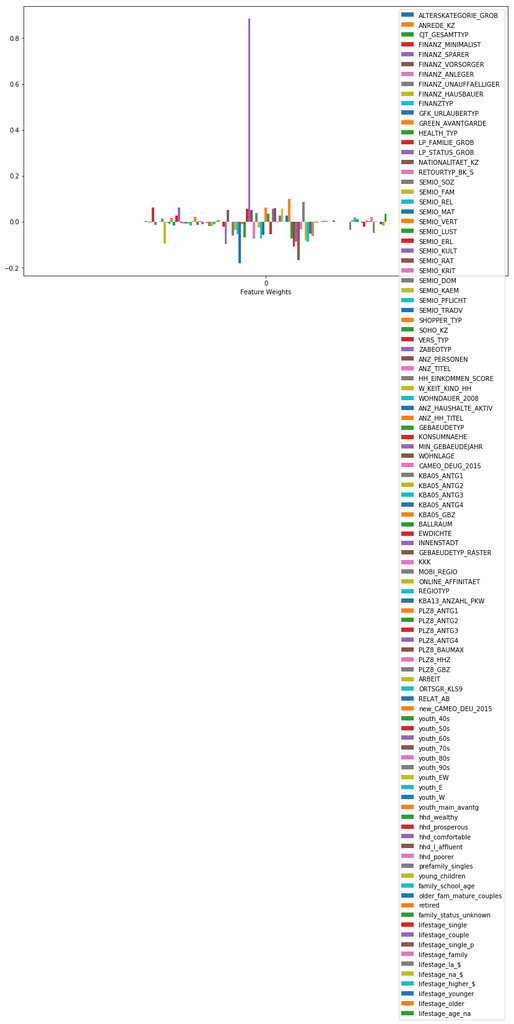

```python
# Map weights for the second principal component to corresponding feature names
# and then print the linked values, sorted by weight.

principal_compo = [0]

visualize_components(principal_compo)
```

```python
print(df_graph.loc[0].sort_values(ascending=False).head(10))
```

```
MIN_GEBAEUDEJAHR      0.884382
PLZ8_ANTG1            0.099069
PLZ8_GBZ              0.086502
KBA05_GBZ             0.063193
FINANZ_MINIMALIST     0.062642
LP_STATUS_GROB        0.060806
GEBAEUDETYP_RASTER    0.060535
INNENSTADT            0.057718
KONSUMNAEHE           0.056815
ONLINE_AFFINITAET     0.056145
Name: 0, dtype: float64
```

## Feature weights scoring high on this graph of 0_th component

(+ effect items)

top earner new home maker in urban area

### MIN_GEBAEUDEJAHR 0.884382

First year building was mentioned in the database -- new home

### PLZ8_ANTG1 0.099069

Number of 1-2 family houses in the PLZ8 region

### PLZ8_GBZ 0.086502

Number of buildings within the PLZ8 region -- high

### KBA05_GBZ 0.063193

Number of buildings in the microcell - high

### FINANZ_MINIMALIST 0.062642

low financial interest - low

### LP_STATUS_GROB 0.060806

TOP EARNERS

### GEBAEUDETYP_RASTER 0.060535

Ratio of residential to commercial activity - RESIDENTIAL

### INNENSTADT 0.057718

Distance to city center (downtown) - MORE THAN 40KM

### KONSUMNAEHE 0.056815

Distance from building to point of sale (PoS) - FURTHER

### ONLINE_AFFINITAET 0.056145

Online affinity - HIGHER

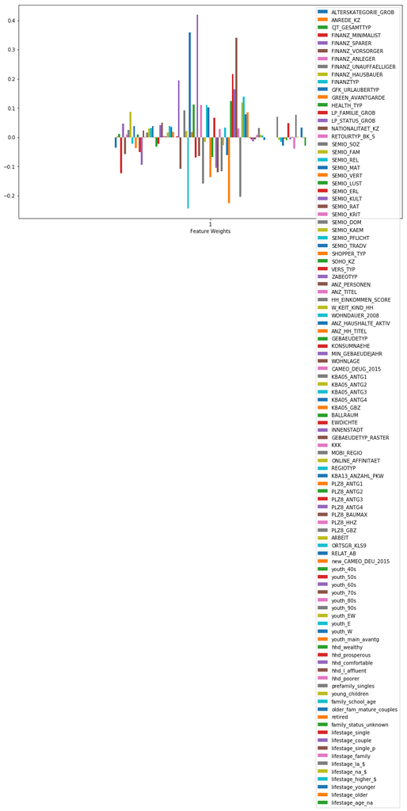

```python
visualize_components([1])
```

```python
print(df_graph.loc[1].sort_values(ascending=False).head(10))
```

```
MIN_GEBAEUDEJAHR       0.419149
ANZ_HAUSHALTE_AKTIV    0.359288
PLZ8_BAUMAX            0.340943
PLZ8_ANTG3             0.215673
ZABEOTYP               0.193732
PLZ8_ANTG4             0.163903
ORTSGR_KLS9            0.139297
PLZ8_ANTG2             0.122918
ARBEIT                 0.119023
GEBAEUDETYP            0.111429
Name: 1, dtype: float64
```

## Feature weights scoring high on this graph of 1_st component

(+ factors)

city dwellers in new home

### MIN_GEBAEUDEJAHR 0.419149

First year building was mentioned in the database -- new home

### ANZ_HAUSHALTE_AKTIV 0.359288

Number of households in the building -- higher

### PLZ8_BAUMAX 0.340943

Most common building type within the PLZ8 region - buseinss buildings

### PLZ8_ANTG3 0.215673

Number of 6-10 family houses in the PLZ8 region - higher

### ZABEOTYP 0.193732

Energy consumption typology - unknown

### PLZ8_ANTG4 0.163903

Number of 10+ family houses in the PLZ8 region - higher

### ORTSGR_KLS9 0.139297

Size of community - bigger

### PLZ8_ANTG2 0.122918

Number of 3-5 family houses in the PLZ8 region - higher

### ARBEIT 0.119023

Share of unemployment in community - higher

### GEBAEUDETYP 0.111429

Type of building (residential vs. commercial) - mixed

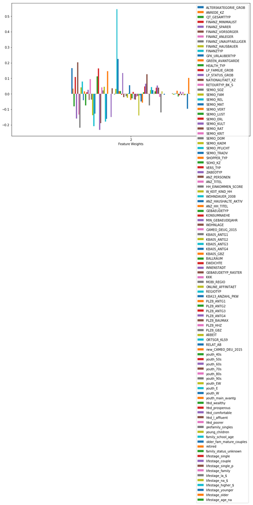

```python
# Map weights for the third principal component to corresponding feature names
# and then print the linked values, sorted by weight.

principal_compo = [2]

visualize_components(principal_compo)
```

```python
print(df_graph.loc[2].sort_values(ascending=False).head(10))
```

```
WOHNDAUER_2008          0.545736
ANZ_HAUSHALTE_AKTIV     0.224839
FINANZ_VORSORGER        0.203929
ALTERSKATEGORIE_GROB    0.165666
SEMIO_ERL               0.164625
SHOPPER_TYP             0.145747
MIN_GEBAEUDEJAHR        0.134007
PLZ8_BAUMAX             0.126031
SEMIO_LUST              0.112255
FINANZ_MINIMALIST       0.108699
Name: 2, dtype: float64
```